# GBSG Analysis: Cox vs. Poisson-Offset Comparison

ForestSearch GLM Extension — Sanity Check

Author

Larry F. León

Published

March 24, 2026

```r
knitr::opts_chunk$set(comment = "#>")

# Navigate to package root
while (!file.exists("DESCRIPTION") && getwd() != dirname(getwd())) {
  setwd("..")
}
stopifnot(
  "Could not find package root" = file.exists("DESCRIPTION")
)

devtools::document(quiet = TRUE)
devtools::load_all(".", quiet = TRUE)

# Source dev/glm closures (not yet graduated to R/)
source("dev/glm/glm_effect_estimators.R")
source("dev/glm/glm_simulate.R")

suppressPackageStartupMessages({
  library(survival)
  library(future)
})

n_cores <- max(1L, parallel::detectCores(logical = FALSE) - 1L)
cat("Package root:", getwd(), "\n")
```

```
Package root: /Users/larryleon/Documents/GitHub/forestsearch
```

```r
cat("R version:", R.version.string, "\n")
```

```
R version: R version 4.5.2 (2025-10-31)
```

```r
cat("Workers:", n_cores, "\n")
```

```
Workers: 13
```

# 1 Data Preparation

The GBSG breast cancer dataset (`survival::gbsg`, N = 686) is prepared identically for both the Cox and Poisson-offset analyses.

```r
df.analysis <- survival::gbsg
df.analysis$id <- seq_len(nrow(df.analysis))
df.analysis$grade3 <- as.integer(df.analysis$grade == "3")

confounders.name <- c("age", "meno", "size", "grade3", "nodes", "pgr", "er")
outcome.name     <- "rfstime"
event.name       <- "status"
treat.name       <- "hormon"
id.name          <- "id"

cat("GBSG: N =", nrow(df.analysis),
    ", events =", sum(df.analysis[[event.name]]),
    sprintf("(%.0f%%)\n", 100 * mean(df.analysis[[event.name]])))
```

```
#> GBSG: N = 686 , events = 299 (44%)
```

# 2 Cox Survival Analysis (Reference)

This is the standard ForestSearch analysis from the primary vignette.

```
#> GRF subgroup: er <= 0
#> GRF cuts identified: 1
#>   Cuts: er <= 0
#> Cox-LASSO selected: 4 of 7 candidate factors
#>   Omitted: age, meno, er
#> Candidate factors: 14
#>  [1] "er <= 0"      "size <= 29.3" "size <= 25"   "size <= 20"   "size <= 35"
#>  [6] "nodes <= 5"   "nodes <= 3"   "nodes <= 1"   "nodes <= 7"   "pgr <= 110"
#> [11] "pgr <= 32.5"  "pgr <= 7"     "pgr <= 131.8" "grade3"
#> Number of possible configurations (<= maxk): maxk = 2 , # combinations = 406
#> Events criteria: control >= 12 , treatment >= 12
#> Sample size criteria: n >= 60
#> Subgroup search completed in 0.01 minutes
#>
#> --- Filtering Summary ---
#>   Combinations evaluated: 406
#>   Passed variance check: 374
#>   Passed prevalence (>= 0.025 ): 374
#>   Passed redundancy check: 354
#>   Passed event counts (d0>= 12 , d1>= 12 ): 250
#>   Passed sample size (n>= 60 ): 247
#>   Cox model fit successfully: 247
#>   Passed HR threshold (>= 1.25 ): 7
#> -------------------------
#>
#> Found 7 subgroup candidate(s)
#> # of candidate subgroups (meeting all criteria) = 7
#> # of unique initial candidates: 7
#> # Restricting to top stop_Kgroups = 3
#> # of candidates to evaluate: 3
#> # Early stop threshold: 0.8
#>
#> ================================================================================
#> TOP 3 CANDIDATE SUBGROUPS FOR CONSISTENCY EVALUATION
#> Sorted by: hr
#> ================================================================================
#>
#> Rank   HR        N       Events  K    Subgroup Definition
#> --------------------------------------------------------------------------------
#> 1      2.537     61      34      2    {er <= 0} & {size <= 35}
#> 2      2.222     75      41      2    {er <= 0} & {pgr <= 32.5}
#> 3      2.054     61      35      2    {er <= 0} & !{size <= 20}
#> --------------------------------------------------------------------------------
```

```
#> Parallel config: workers = 13 , batch_size = 1
#> Batch 1 / 3 : candidates 1 - 1
#>
#> ==================================================
#> EARLY STOP TRIGGERED (batch 1 )
#>   Candidate: 1 of 3
#>   Pcons: 0.97 >= 0.8
#> ==================================================
#>
#> Evaluated 1 of 3 candidates (early stop)
#> 1 subgroups passed consistency threshold
```

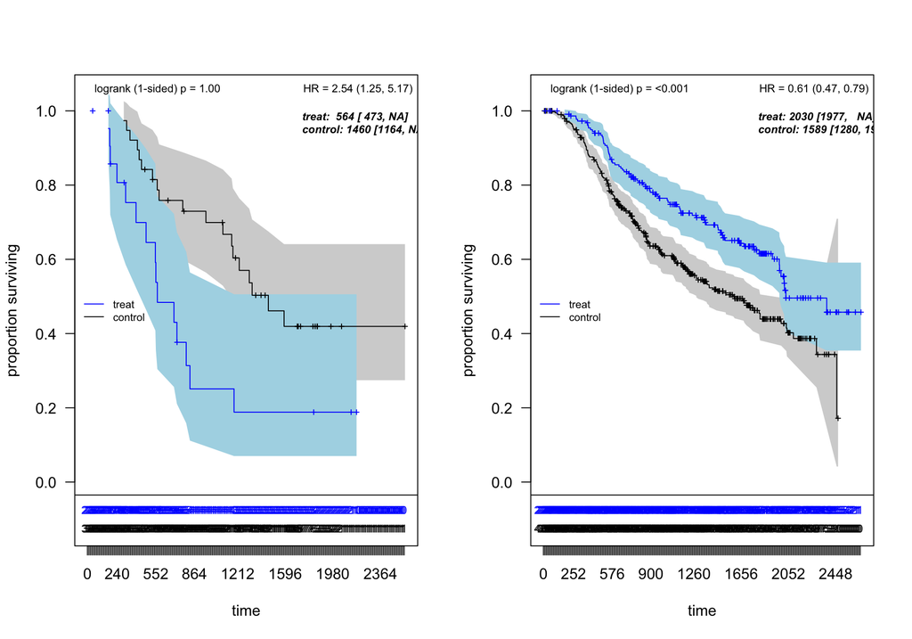

```
#> *** Subgroup found: {er <= 0} {size <= 35}
#> % consistency criteria met= 0.97
#> SG focus = hr
#> Seconds and minutes forestsearch overall = 1.096 0.0183
#> Consistency algorithm used: twostage
#> Subgroup identified: {er <= 0} & {size <= 35}
```

```r
fs_cox <- forestsearch(
  df.analysis,
  confounders.name = confounders.name,
  outcome.name     = outcome.name,
  treat.name       = treat.name,
  event.name       = event.name,
  id.name          = id.name,
  # Threshold parameters (per León et al. 2024)
  hr.threshold           = 1.25,
  hr.consistency         = 1.0,
  pconsistency.threshold = 0.80,
  stop_threshold         = 0.80,
  # Search configuration
  sg_focus             = "hr",
  max_subgroups_search = 3,
  use_twostage         = TRUE,
  # Factor selection
  use_grf                    = TRUE,
  return_selected_cuts_only  = TRUE,
  use_lasso                  = TRUE,
  cut_type                   = "default",
  # Subgroup constraints
  maxk   = 2,
  n.min  = 60,
  d0.min = 12,
  d1.min = 12,
  # Consistency evaluation
  fs.splits = 100,
  # Sequential for load_all() compatibility
  parallel_args = list(
    plan         = "sequential",
    workers      = n_cores,
    show_message = TRUE
  ),
  # Output options
  showten_subgroups = TRUE,
  details           = TRUE,
  plot.sg           = TRUE
)
```

```r
plan("sequential")
```

## 2.1 Cox Results

### 2.1.1 Identified Subgroups

```r
res_cox <- sg_tables(fs_cox, ndecimals = 3, which_df = "est")
res_cox$sg10_out
```

**Identified Subgroups**

Two-factor subgroups (maxk=2)

| Factor 1 | Factor 2 | N | Events | E<sub>1</sub> | HR | P<sub>cons</sub> |
| --- | --- | --- | --- | --- | --- | --- |
| {er <= 0} | {size <= 35} | 61 | 34 | 15 | 2.537 | 0.970 |

**Search Configuration:** Single-factor candidates (L) = 28; Maximum combinations evaluated = 406; Search depth (maxk) = 2  
**Search Results:** Candidate subgroups found = 7; Maximum HR estimate = 2.54  
**Note:** E<sub>1</sub> = events in treatment arm; P<sub>cons</sub> = consistency proportion

### 2.1.2 Treatment Effect Estimates

```r
res_cox$tab_estimates
```

**Treatment Effect Estimates**

Training data estimates

| Subgroup | n | n1 | events | m1 | m0 | RMST | HR (95% CI) |
| --- | --- | --- | --- | --- | --- | --- | --- |
| ITT | 686 (100.0%) | 246 (35.9%) | 299 (43.6%) | 2018 | 1528 | 240 | 0.69 (0.54, 0.89) |
| Questionable<sup>1</sup> | 61 (8.9%) | 23 (37.7%) | 34 (55.7%) | 564 | 1460 | -580 | 2.54 (1.25, 5.17) |
| Recommend | 625 (91.1%) | 223 (35.7%) | 265 (42.4%) | 2030 | 1589 | 290 | 0.61 (0.47, 0.79) |

<sup>1</sup> **Identified subgroup** : {er <= 0} & {size <= 35}

### 2.1.3 Identified Subgroup Definition

```r
cat("Identified subgroup (H):", paste(fs_cox$sg.harm, collapse = " & "), "\n")
```

```
#> Identified subgroup (H): {er <= 0} & {size <= 35}
```

```r
cat("Subgroup size:", sum(fs_cox$df.est$treat.recommend == 0),
    sprintf("(%.1f%% of ITT)\n",
            100 * mean(fs_cox$df.est$treat.recommend == 0)))
```

```
#> Subgroup size: 61 (8.9% of ITT)
```

# 3 Poisson-Offset GLM Analysis (Sanity Check)

The Poisson regression with `log(rfstime)` as offset approximates the Cox model when the baseline hazard is locally constant. Under this approximation, `exp(log-IRR)` should track the Cox hazard ratio, and the identified subgroup should be similar or identical.

The key API difference: `outcome.name` is the binary event indicator, `offset.name` points to the follow-up time column, and `outcome_type = "binary"` with `effect_measure = "IRR"`.

**NoteGRF and LASSO not yet wired for GLM outcomes (Phase 1)**

The Poisson-offset analysis disables GRF and LASSO candidate selection because these components use `causal_survival_forest()` and `glmnet(family = "cox")` respectively, which require survival-specific inputs. Wiring `causal_forest()` and `glmnet(family = "poisson")` is Phase 3 work. For now, all confounders are cut at quartiles/median (the `cut_type = "default"` path).

```r
fs_pois <- forestsearch(
  df.analysis,
  confounders.name = confounders.name,
  conf_force = c("er <= 0"),
  outcome.name     = event.name,        # binary event indicator (0/1)
  event.name       = event.name,        # same column (binary IS the event)
  treat.name       = treat.name,
  id.name          = id.name,
  # GLM outcome specification
  outcome_type     = "binary",
  effect_measure   = "IRR",
  offset.name      = outcome.name,      # "rfstime" — log(rfstime) used as offset
  # Threshold parameters — same as Cox for comparability
  # IRR thresholds map directly to HR thresholds
  hr.threshold           = 1.25,        # log(1.25) screening on log-IRR scale
  hr.consistency         = 1.0,         # log(1.0) = 0 consistency threshold
  pconsistency.threshold = 0.80,
  stop_threshold         = 0.80,
  # Search configuration
  sg_focus             = "hr",
  max_subgroups_search = 3,
  use_twostage         = TRUE,
  # Factor selection — GRF/LASSO not yet wired for GLM (Phase 1)
  use_grf   = FALSE,
  use_lasso = FALSE,
  cut_type  = "default",
  # Subgroup constraints
  maxk   = 2,
  n.min  = 60,
  d0.min = 12,
  d1.min = 12,
  # Consistency evaluation
  fs.splits = 100,
  # Sequential for load_all() compatibility
  parallel_args = list(
    plan         = "sequential",
    workers      = n_cores,
    show_message = TRUE
  ),
  # Output options
  showten_subgroups = TRUE,
  details           = TRUE,
  plot.sg           = FALSE              # KM plots not applicable for GLM
)
```

```
#> GLM mode: outcome_type = binary , effect_measure = IRR
#>   Screening threshold: 0.2231436
#>   Consistency threshold: 0
#> Forced confounders: er <= 0
#> Candidate factors: 23
#>  [1] "er <= 0"      "age <= 53.1"  "age <= 53"    "age <= 46"    "age <= 61"
#>  [6] "size <= 29.3" "size <= 25"   "size <= 20"   "size <= 35"   "nodes <= 5"
#> [11] "nodes <= 3"   "nodes <= 1"   "nodes <= 7"   "pgr <= 110"   "pgr <= 32.5"
#> [16] "pgr <= 7"     "pgr <= 131.8" "er <= 96.3"   "er <= 36"     "er <= 8"
#> [21] "er <= 114"    "meno"         "grade3"
#> Number of possible configurations (<= maxk): maxk = 2 , # combinations = 1081
#> Events criteria: control >= 12 , treatment >= 12
#> Sample size criteria: n >= 60
#> Subgroup search completed in 0.02 minutes
#>
#> --- Filtering Summary ---
#>   Combinations evaluated: 1081
#>   Passed variance check: 1022
#>   Passed prevalence (>= 0.025 ): 1022
#>   Passed redundancy check: 980
#>   Passed event counts (d0>= 12 , d1>= 12 ): 929
#>   Passed sample size (n>= 60 ): 859
#>   Cox model fit successfully: 859
#>   Passed HR threshold (>= 0.2231436 ): 17
#> -------------------------
#>
#> Found 17 subgroup candidate(s)
#> # of candidate subgroups (meeting all criteria) = 17
#> # of unique initial candidates: 17
#> # Restricting to top stop_Kgroups = 3
#> # of candidates to evaluate: 3
#> # Early stop threshold: 0.8
#>
#> ================================================================================
#> TOP 3 CANDIDATE SUBGROUPS FOR CONSISTENCY EVALUATION
#> Sorted by: hr
#> ================================================================================
#>
#> Rank   HR        N       Events  K    Subgroup Definition
#> --------------------------------------------------------------------------------
#> 1      0.813     61      61      2    {er <= 0} & {size <= 35}
#> 2      0.773     75      75      2    {er <= 0} & {pgr <= 32.5}
#> 3      0.751     61      61      2    {er <= 0} & {nodes <= 7}
#> --------------------------------------------------------------------------------
```

```
#> Parallel config: workers = 13 , batch_size = 1
#> Batch 1 / 3 : candidates 1 - 1
#>
#> ==================================================
#> EARLY STOP TRIGGERED (batch 1 )
#>   Candidate: 1 of 3
#>   Pcons: 0.97 >= 0.8
#> ==================================================
#>
#> Evaluated 1 of 3 candidates (early stop)
#> 1 subgroups passed consistency threshold
#> SG focus = hr
#> Seconds and minutes forestsearch overall = 1.554 0.0259
#> Consistency algorithm used: twostage
#> Subgroup identified: {er <= 0} & {size <= 35}
```

```r
plan("sequential")
```

## 3.1 Poisson-Offset Results

### 3.1.1 Identified Subgroup Definition

```r
if (!is.null(fs_pois$sg.harm)) {
  cat("Identified subgroup (H):", paste(fs_pois$sg.harm, collapse = " & "), "\n")
  cat("Subgroup size:", sum(fs_pois$df.est$treat.recommend == 0),
      sprintf("(%.1f%% of ITT)\n",
              100 * mean(fs_pois$df.est$treat.recommend == 0)))
} else {
  cat("No subgroup identified by Poisson-offset path\n")
}
```

```
#> Identified subgroup (H): {er <= 0} & {size <= 35}
#> Subgroup size: 61 (8.9% of ITT)
```

### 3.1.2 Candidate Subgroups from Search

```r
pois_cands <- fs_pois$find.grps$out.found$hr.subgroups
if (!is.null(pois_cands) && nrow(pois_cands) > 0) {
  # HR column contains log-IRR in the GLM path; exponentiate for comparison
  pois_cands$IRR <- exp(pois_cands$HR)

  factor_cols <- setdiff(
    names(pois_cands),
    c("grp", "K", "n", "E", "d1", "m1", "m0", "HR", "L(HR)", "U(HR)", "IRR")
  )

  cat("Top candidates (sorted by IRR):\n\n")
  top <- head(pois_cands[order(-pois_cands$IRR), ], 10)
  for (i in seq_len(nrow(top))) {
    active <- factor_cols[
      as.numeric(unlist(top[i, factor_cols, with = FALSE])) == 1
    ]
    cat(sprintf("  #%d: log-IRR = %6.3f  (IRR = %5.2f)  n = %3d  %s\n",
                i, top$HR[i], top$IRR[i], top$n[i],
                paste(active, collapse = " & ")))
  }
} else {
  cat("No candidates found\n")
}
```

```
#> Top candidates (sorted by IRR):
#>
#>   #1: log-IRR =  0.813  (IRR =  2.25)  n =  61  q1.1 & q9.1
#>   #2: log-IRR =  0.773  (IRR =  2.17)  n =  75  q1.1 & q15.1
#>   #3: log-IRR =  0.751  (IRR =  2.12)  n =  61  q1.1 & q13.1
#>   #4: log-IRR =  0.657  (IRR =  1.93)  n =  61  q1.1 & q8.0
#>   #5: log-IRR =  0.628  (IRR =  1.87)  n =  64  q1.1 & q16.1
#>   #6: log-IRR =  0.607  (IRR =  1.84)  n =  82  q1.1
#>   #7: log-IRR =  0.526  (IRR =  1.69)  n =  76  q6.0 & q20.1
#>   #8: log-IRR =  0.525  (IRR =  1.69)  n =  68  q16.1 & q22.0
#>   #9: log-IRR =  0.494  (IRR =  1.64)  n =  72  q16.1 & q23.1
#>   #10: log-IRR =  0.464  (IRR =  1.59)  n =  64  q1.1 & q5.1
```

# 4 Side-by-Side Comparison

```r
cat("=" |> rep(70) |> paste(collapse = ""), "\n")
cat("GBSG Subgroup Identification: Cox vs. Poisson-Offset\n")
```

```
#> GBSG Subgroup Identification: Cox vs. Poisson-Offset
```

```r
cat("=" |> rep(70) |> paste(collapse = ""), "\n\n")
# Cox results
cat("Cox (survival) path:\n")
```

```
#> Cox (survival) path:
```

```r
if (!is.null(fs_cox$sg.harm)) {
  cat("  Subgroup: ", paste(fs_cox$sg.harm, collapse = " & "), "\n")
  cat("  N(harm):  ", sum(fs_cox$df.est$treat.recommend == 0), "\n")
  cat("  N(benefit):", sum(fs_cox$df.est$treat.recommend == 1), "\n")
} else {
  cat("  No subgroup identified\n")
}
```

```
#>   Subgroup:  {er <= 0} & {size <= 35}
#>   N(harm):   61
#>   N(benefit): 625
```

```r
cat("\nPoisson-offset (GLM) path:\n")
```

```
#>
#> Poisson-offset (GLM) path:
```

```r
if (!is.null(fs_pois$sg.harm)) {
  cat("  Subgroup: ", paste(fs_pois$sg.harm, collapse = " & "), "\n")
  cat("  N(harm):  ", sum(fs_pois$df.est$treat.recommend == 0), "\n")
  cat("  N(benefit):", sum(fs_pois$df.est$treat.recommend == 1), "\n")
} else {
  cat("  No subgroup identified\n")
}
```

```
#>   Subgroup:  {er <= 0} & {size <= 35}
#>   N(harm):   61
#>   N(benefit): 625
```

```r
# ITT-level comparison of Cox log-HR vs Poisson log-IRR
cat("\nITT-level effect estimates:\n")
```

```
#>
#> ITT-level effect estimates:
```

```r
cox_itt <- survival::coxph(
  survival::Surv(rfstime, status) ~ hormon, data = df.analysis
)
pois_itt <- glm(
  status ~ hormon, family = poisson(link = "log"),
  offset = log(rfstime), data = df.analysis
)
cat("  Cox  log-HR: ", round(coef(cox_itt)["hormon"], 4), "\n")
```

```
#>   Cox  log-HR:  -0.364
```

```r
cat("  Pois log-IRR:", round(coef(pois_itt)["hormon"], 4), "\n")
```

```
#>   Pois log-IRR: -0.3556
```

```r
cat("  Difference:  ", round(coef(pois_itt)["hormon"] - coef(cox_itt)["hormon"], 4), "\n")
```

```
#>   Difference:   0.0084
```

**NoteInterpreting the Comparison**

The Cox and Poisson-offset paths may identify **different subgroups** for two reasons:

1. **Candidate factor sets differ.** The Cox path uses GRF + LASSO for variable selection; the Poisson path uses quartile cuts only (Phase 1). This means the Cox path evaluates a smaller, more targeted set of candidates.
2. **The Poisson approximation is imperfect.** The GBSG data has a Weibull-like hazard (not constant), so the Poisson log-IRR diverges slightly from the Cox log-HR, especially in subgroups with heterogeneous follow-up.

Despite these differences, the ITT-level estimates should agree closely, and the identified subgroups should share common factors (particularly estrogen receptor status, which is the dominant prognostic/predictive variable in this dataset).

When GRF and LASSO are wired for GLM outcomes (Phase 3), the candidate sets will align and the comparison will be tighter.